# dada2 analysis for blue-jam project

jen nguyen

9/7/2021

```r
library(dada2); packageVersion("dada2")
```

```
[1] ‘1.20.0’
```

```r
library(ggplot2)
library(here)
library(phyloseq)
library(Biostrings)
library(tidyverse)
library(fs)
```

```r
path_raw <- here::here("data/reads/raw")
path_filtered <- here::here("data/reads/filtered")
list.files(path_raw)
```

```
 [1] "JN01_S159_R1_001.fastq.gz"   "JN01_S159_R2_001.fastq.gz"   "JN02_S160_R1_001.fastq.gz"
 [4] "JN02_S160_R2_001.fastq.gz"   "JN03_S161_R1_001.fastq.gz"   "JN03_S161_R2_001.fastq.gz"
 [7] "JN04_S162_R1_001.fastq.gz"   "JN04_S162_R2_001.fastq.gz"   "JN05_S163_R1_001.fastq.gz"
[10] "JN05_S163_R2_001.fastq.gz"   "JN06_S164_R1_001.fastq.gz"   "JN06_S164_R2_001.fastq.gz"
[13] "JN07_S165_R1_001.fastq.gz"   "JN07_S165_R2_001.fastq.gz"   "JN08_S166_R1_001.fastq.gz"
[16] "JN08_S166_R2_001.fastq.gz"   "JN09_S167_R1_001.fastq.gz"   "JN09_S167_R2_001.fastq.gz"
[19] "JN10_S168_R1_001.fastq.gz"   "JN10_S168_R2_001.fastq.gz"   "JN11_S169_R1_001.fastq.gz"
[22] "JN11_S169_R2_001.fastq.gz"   "JN12_S170_R1_001.fastq.gz"   "JN12_S170_R2_001.fastq.gz"
[25] "JN13_S171_R1_001.fastq.gz"   "JN13_S171_R2_001.fastq.gz"   "JN14_S172_R1_001.fastq.gz"
[28] "JN14_S172_R2_001.fastq.gz"   "JN15_S173_R1_001.fastq.gz"   "JN15_S173_R2_001.fastq.gz"
[31] "JN16_S174_R1_001.fastq.gz"   "JN16_S174_R2_001.fastq.gz"   "JN17_S156_R1_001.fastq.gz"
[34] "JN17_S156_R2_001.fastq.gz"   "JN18_S157_R1_001.fastq.gz"   "JN18_S157_R2_001.fastq.gz"
[37] "mock-_S101_R1_001.fastq.gz"  "mock-_S101_R2_001.fastq.gz"  "mock-2_S109_R1_001.fastq.gz"
[40] "mock-2_S109_R2_001.fastq.gz" "NTC_S95_R1_001.fastq.gz"     "NTC_S95_R2_001.fastq.gz"
[43] "NTC-2_S158_R1_001.fastq.gz"  "NTC-2_S158_R2_001.fastq.gz"  "raw"
[46] "reads.md5"
```

```r
# Forward and reverse fastq filenames have format: SAMPLENAME_R1_001.fastq and SAMPLENAME_R2_001.fastq
fnFs <- sort(list.files(path_raw, pattern="_R1_001.fastq", full.names = TRUE))
fnRs <- sort(list.files(path_raw, pattern="_R2_001.fastq", full.names = TRUE))
fnFs %>% path_file %>% head
```

```
[1] "JN01_S159_R1_001.fastq.gz" "JN02_S160_R1_001.fastq.gz" "JN03_S161_R1_001.fastq.gz"
[4] "JN04_S162_R1_001.fastq.gz" "JN05_S163_R1_001.fastq.gz" "JN06_S164_R1_001.fastq.gz"
```

```r
# Extract sample names, assuming filenames have format: SAMPLENAME_XXX.fastq
sample.names <- sapply(strsplit(basename(fnFs), "_"), `[`, 1)
print(sample.names)
```

```
 [1] "JN01"   "JN02"   "JN03"   "JN04"   "JN05"   "JN06"   "JN07"   "JN08"   "JN09"   "JN10"   "JN11"   "JN12"
[13] "JN13"   "JN14"   "JN15"   "JN16"   "JN17"   "JN18"   "mock-"  "mock-2" "NTC"    "NTC-2"
```

```
`guides(<scale> = FALSE)` is deprecated. Please use `guides(<scale> = "none")` instead.
```

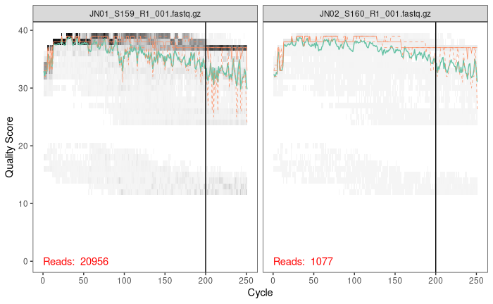

```r
plotQualityProfile(fnFs[1:2]) +
  geom_vline(xintercept = 200) # truncation length of forward reads
```

```
`guides(<scale> = FALSE)` is deprecated. Please use `guides(<scale> = "none")` instead.
```

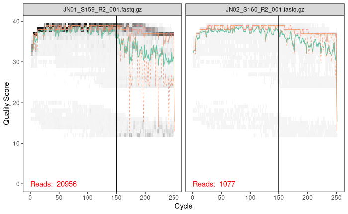

```r
plotQualityProfile(fnRs[1:2]) +
  geom_vline(xintercept = 150) # truncation length of reverse reads
```

```
`guides(<scale> = FALSE)` is deprecated. Please use `guides(<scale> = "none")` instead.
```

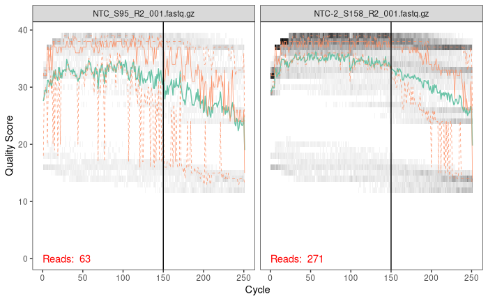

```r
plotQualityProfile(tail(fnRs,2)) +
  geom_vline(xintercept = 150) # truncation length of reverse reads
```

```r
# Place filtered files in filtered/ subdirectory
filtFs <- file.path(path_filtered, paste0(sample.names, "_F_filt.fastq.gz"))
filtRs <- file.path(path_filtered, paste0(sample.names, "_R_filt.fastq.gz"))
names(filtFs) <- sample.names
names(filtRs) <- sample.names
```

```r
out <- filterAndTrim(fnFs, filtFs, fnRs, filtRs, truncLen=c(248,225),
              maxN=0, maxEE=c(2,2), truncQ=2, rm.phix=TRUE,
              compress=TRUE, multithread=TRUE) # On Windows set multithread=FALSE
head(out)
```

```r
out <- filterAndTrim(fnFs, filtFs, fnRs, filtRs, truncLen=c(200,150),
              maxN=0, maxEE=c(2,2), truncQ=2, rm.phix=TRUE,
              compress=TRUE, multithread=TRUE) # On Windows set multithread=FALSE
head(out)
```

```
                          reads.in reads.out
JN01_S159_R1_001.fastq.gz    20956     19940
JN02_S160_R1_001.fastq.gz     1077      1051
JN03_S161_R1_001.fastq.gz      515       472
JN04_S162_R1_001.fastq.gz    10170      9515
JN05_S163_R1_001.fastq.gz     5168      5017
JN06_S164_R1_001.fastq.gz     6761      6590
```

More filtered reads by truncating raw reads by more bp! We are only sequencing V4 in this data.

```r
# Learn the Error Rates
errF <- learnErrors(filtFs, multithread=TRUE)
```

```
50340800 total bases in 251704 reads from 22 samples will be used for learning the error rates.
```

```r
errR <- learnErrors(filtRs, multithread=TRUE)
```

```
37755600 total bases in 251704 reads from 22 samples will be used for learning the error rates.
```

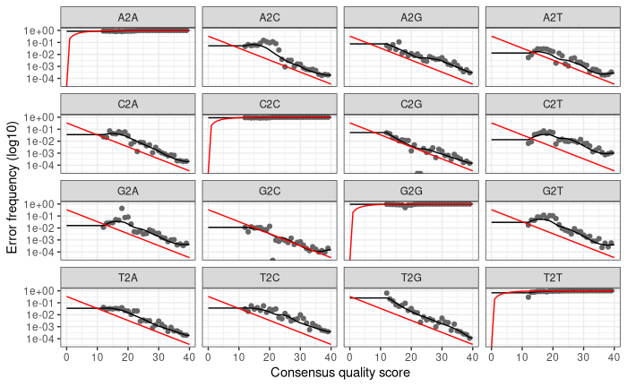

```r
plotErrors(errF, nominalQ=TRUE)
```

Wisdoms from Mike: DADA2 uses our own data (dots) to calculate error rates (model = black line). Sometimes the expected error based on the nominal definition of Q-score (red line) matches error seen in our data. But often, we have a higher error rate and DADA2 will use this.

More sequencing data is more info for the model. A good fit between model and observed data (black line and dots) means We now have good understanding of error rates in our data!

```r
# Sample Inference
dadaFs <- dada(filtFs, err=errF, multithread=TRUE)
```

```
Sample 1 - 19940 reads in 2874 unique sequences.
Sample 2 - 1051 reads in 255 unique sequences.
Sample 3 - 472 reads in 252 unique sequences.
Sample 4 - 9515 reads in 1948 unique sequences.
Sample 5 - 5017 reads in 856 unique sequences.
Sample 6 - 6590 reads in 1199 unique sequences.
Sample 7 - 27540 reads in 4159 unique sequences.
Sample 8 - 1952 reads in 538 unique sequences.
Sample 9 - 1110 reads in 288 unique sequences.
Sample 10 - 766 reads in 255 unique sequences.
Sample 11 - 483 reads in 250 unique sequences.
Sample 12 - 504 reads in 221 unique sequences.
Sample 13 - 265 reads in 117 unique sequences.
Sample 14 - 3532 reads in 697 unique sequences.
Sample 15 - 2566 reads in 579 unique sequences.
Sample 16 - 166 reads in 112 unique sequences.
Sample 17 - 661 reads in 183 unique sequences.
Sample 18 - 163 reads in 53 unique sequences.
Sample 19 - 61234 reads in 4658 unique sequences.
Sample 20 - 108078 reads in 6187 unique sequences.
Sample 21 - 35 reads in 26 unique sequences.
Sample 22 - 64 reads in 35 unique sequences.
```

```r
dadaRs <- dada(filtRs, err=errR, multithread=TRUE)
```

```
Sample 1 - 19940 reads in 1875 unique sequences.
Sample 2 - 1051 reads in 224 unique sequences.
Sample 3 - 472 reads in 247 unique sequences.
Sample 4 - 9515 reads in 1209 unique sequences.
Sample 5 - 5017 reads in 754 unique sequences.
Sample 6 - 6590 reads in 941 unique sequences.
Sample 7 - 27540 reads in 3256 unique sequences.
Sample 8 - 1952 reads in 429 unique sequences.
Sample 9 - 1110 reads in 240 unique sequences.
Sample 10 - 766 reads in 209 unique sequences.
Sample 11 - 483 reads in 213 unique sequences.
Sample 12 - 504 reads in 183 unique sequences.
Sample 13 - 265 reads in 117 unique sequences.
Sample 14 - 3532 reads in 533 unique sequences.
Sample 15 - 2566 reads in 505 unique sequences.
Sample 16 - 166 reads in 103 unique sequences.
Sample 17 - 661 reads in 159 unique sequences.
Sample 18 - 163 reads in 54 unique sequences.
Sample 19 - 61234 reads in 3446 unique sequences.
Sample 20 - 108078 reads in 4781 unique sequences.
Sample 21 - 35 reads in 25 unique sequences.
Sample 22 - 64 reads in 36 unique sequences.
```

```r
dadaFs[[1]]
```

```
dada-class: object describing DADA2 denoising results
183 sequence variants were inferred from 2874 input unique sequences.
Key parameters: OMEGA_A = 1e-40, OMEGA_C = 1e-40, BAND_SIZE = 16
```

Notes from DADA2 tutorial: The DADA2 algorithm inferred 183 true sequence variants from the 2874 unique sequences in the first sample. There is much more to the dada-class return object than this (see help(“dada-class”) for some info), including multiple diagnostics about the quality of each denoised sequence variant, but that is beyond the scope of an introductory tutorial.

```r
# Merge Paired Reads
mergers <- mergePairs(dadaFs, filtFs, dadaRs, filtRs, verbose=TRUE)
```

```
19515 paired-reads (in 157 unique pairings) successfully merged out of 19739 (in 230 pairings) input.
911 paired-reads (in 52 unique pairings) successfully merged out of 974 (in 70 pairings) input.
341 paired-reads (in 28 unique pairings) successfully merged out of 373 (in 41 pairings) input.
9020 paired-reads (in 134 unique pairings) successfully merged out of 9331 (in 224 pairings) input.
4747 paired-reads (in 96 unique pairings) successfully merged out of 4891 (in 129 pairings) input.
6286 paired-reads (in 118 unique pairings) successfully merged out of 6447 (in 164 pairings) input.
26763 paired-reads (in 194 unique pairings) successfully merged out of 27199 (in 350 pairings) input.
1727 paired-reads (in 77 unique pairings) successfully merged out of 1839 (in 110 pairings) input.
1009 paired-reads (in 54 unique pairings) successfully merged out of 1044 (in 73 pairings) input.
659 paired-reads (in 40 unique pairings) successfully merged out of 678 (in 53 pairings) input.
361 paired-reads (in 31 unique pairings) successfully merged out of 395 (in 44 pairings) input.
356 paired-reads (in 29 unique pairings) successfully merged out of 399 (in 47 pairings) input.
173 paired-reads (in 20 unique pairings) successfully merged out of 205 (in 31 pairings) input.
3301 paired-reads (in 73 unique pairings) successfully merged out of 3390 (in 110 pairings) input.
2348 paired-reads (in 70 unique pairings) successfully merged out of 2464 (in 108 pairings) input.
111 paired-reads (in 11 unique pairings) successfully merged out of 119 (in 13 pairings) input.
597 paired-reads (in 37 unique pairings) successfully merged out of 623 (in 50 pairings) input.
134 paired-reads (in 5 unique pairings) successfully merged out of 134 (in 5 pairings) input.
60218 paired-reads (in 59 unique pairings) successfully merged out of 60445 (in 95 pairings) input.
107607 paired-reads (in 64 unique pairings) successfully merged out of 107855 (in 122 pairings) input.
18 paired-reads (in 3 unique pairings) successfully merged out of 18 (in 3 pairings) input.
38 paired-reads (in 2 unique pairings) successfully merged out of 38 (in 2 pairings) input.
```

```r
# Inspect the merger data.frame from the first sample
head(mergers[[1]])
```

|  | sequence | abundance | forward | reverse | nmatch | nmismatch | nindel | prefer | accept |
| --- | --- | --- | --- | --- | --- | --- | --- | --- | --- |
| 1 | TACGGAGGATGCGAGCGTTATCCGGATTCATTGGGTTTAAAGGGTGCGCAGGCGGGCCTT…… | 3379 | 2 | 1 | 98 | 0 | 0 | 2 | TRUE |
| 2 | TACGTAGGTGGCAAGCGTTGTCCGGATTTATTGGGCGTAAAGCGAGTGCAGGCGGTTCAA…… | 3170 | 3 | 3 | 97 | 0 | 0 | 2 | TRUE |
| 3 | TACGTAGGTGGCAAGCGTTATCCGGAATTATTGGGCGTAAAGAGCGCGCAGGTGGTTAAT…… | 2990 | 1 | 2 | 97 | 0 | 0 | 2 | TRUE |
| 4 | TACGTAGGTGGCGAGCGTTGTCCGGATTTACTGGGCGTAAAGGGAGCGTAGGCGGACTTT…… | 1482 | 4 | 4 | 97 | 0 | 0 | 1 | TRUE |
| 5 | TACGTAGGGTGCAAGCGTTATCCGGATTTATTGGGCGTAAAGGGCTCGTAGGCGGTTCGT…… | 1318 | 5 | 5 | 97 | 0 | 0 | 2 | TRUE |
| 6 | TACGTAGGGAGCGAGCGTTATCCGGAATTATTGGGCGTAAAGGGTGCGTAGATGGCATAG…… | 513 | 6 | 6 | 98 | 0 | 0 | 2 | TRUE |

```r
# Construct Sequence Table
seqtab <- makeSequenceTable(mergers)
dim(seqtab)
```

```
[1]  22 410
```

This table contains 410 ASVs!

```r
# Inspect distribution of sequence lengths
table(nchar(getSequences(seqtab)))
```

```
251 252 253 254
  1  79 319  11
```

253 bp nicely matches the expected length of V4 region of 16S rRNA. In this run, Gut4Health used an in-house library prep protocol that amplified the V4 region. Next run with these same DNA samples will be a commercial kit that amplifies V3V4.

```r
# Remove Chimeras
seqtab.nochim <- removeBimeraDenovo(seqtab, method="consensus", multithread=TRUE, verbose=TRUE)
```

```
Identified 61 bimeras out of 410 input sequences.
```

```r
dim(seqtab.nochim)
```

```
[1]  22 349
```

```r
# Calculate Fraction of Reads that were Chimeras
sum(seqtab.nochim)/sum(seqtab)
```

```
[1] 0.9869761
```

Chimeras make up a substantial portion (~15%) of merged sequence variants, but are only about 1% of the merge sequenced reads when accounting for the abundance of these variants.

```r
# Track Reads Through the Pipeline
getN <- function(x) sum(getUniques(x))
track <- cbind(out, sapply(dadaFs, getN), sapply(dadaRs, getN), sapply(mergers, getN), rowSums(seqtab.nochim))
# If processing a single sample, remove the sapply calls: e.g. replace sapply(dadaFs, getN) with getN(dadaFs)
colnames(track) <- c("input", "filtered", "denoisedF", "denoisedR", "merged", "nonchim")
rownames(track) <- sample.names
head(track)
```

```
     input filtered denoisedF denoisedR merged nonchim
JN01 20956    19940     19829     19826  19515   19440
JN02  1077     1051      1000      1002    911     911
JN03   515      472       389       426    341     341
JN04 10170     9515      9403      9421   9020    8997
JN05  5168     5017      4928      4958   4747    4747
JN06  6761     6590      6512      6499   6286    6267
```

```r
write.csv(track, here::here('output', 'dada2', 'track.csv'))
```

- Wisdoms from Mike * Some of the lower read count samples are losing lots of reads in the filtering step. We can avoid some loss in various ways, including trimming more to remove noisier overlap. This increased trimming/truncation is especially possible with shorter reads (V4 vs V3V4).

```r
# getting the right name for our taxonomy database files
here('data', 'database') %>% list.files()
```

```
[1] "silva_nr99_v138.1_train_set.fa.gz"     "silva_species_assignment_v138.1.fa.gz"
```

```r
# Assign Taxonomy using the training set
taxa <- assignTaxonomy(
  seqtab.nochim,
  here("data", "database", "silva_nr99_v138.1_train_set.fa.gz"),
  multithread=TRUE
)
```

```r
# Add species
taxa <- addSpecies(
  taxa,
  here("data", "database", "silva_species_assignment_v138.1.fa.gz"),
  allowMultiple = TRUE
)
```

```r
# Inspect taxonomic assignments
taxa.print <- taxa # Removing sequence row names for display only
rownames(taxa.print) <- NULL
head(taxa.print)
```

```
     Kingdom    Phylum           Class                 Order                            Family
[1,] "Bacteria" "Firmicutes"     "Negativicutes"       "Veillonellales-Selenomonadales" "Veillonellaceae"
[2,] "Bacteria" "Firmicutes"     "Negativicutes"       "Veillonellales-Selenomonadales" "Veillonellaceae"
[3,] "Bacteria" "Firmicutes"     "Negativicutes"       "Veillonellales-Selenomonadales" "Veillonellaceae"
[4,] "Bacteria" "Bacteroidota"   "Bacteroidia"         "Bacteroidales"                  "Prevotellaceae"
[5,] "Bacteria" "Proteobacteria" "Gammaproteobacteria" "Enterobacterales"               "Enterobacteriaceae"
[6,] "Bacteria" "Bacteroidota"   "Bacteroidia"         "Bacteroidales"                  "Muribaculaceae"
     Genus                  Species
[1,] "Veillonella"          "atypica/dispar"
[2,] "Veillonella"          "parvula/rogosae/tobetsuensis"
[3,] "Veillonella"          "atypica/parvula"
[4,] "Prevotella"           "corporis"
[5,] "Escherichia-Shigella" NA
[6,] NA                     NA
```

```r
# Evaluate Accuracy
unqs.mock <- seqtab.nochim["mock-",]
unqs.mock <- sort(unqs.mock[unqs.mock>0], decreasing=TRUE) # Drop ASVs absent in the Mock
cat("DADA2 inferred", length(unqs.mock), "sample sequences present in the Mock community.\n")
```

```
DADA2 inferred 29 sample sequences present in the Mock community.
```

The ZymoBIOMICS Gut Microbiome Standard has 21 species! Less truncation gave 21 ASVs in Mock Community whereas more truncation gives 29!

```r
# Evaluate Accuracy
unqs.mock <- seqtab.nochim["mock-2",]
unqs.mock <- sort(unqs.mock[unqs.mock>0], decreasing=TRUE) # Drop ASVs absent in the Mock
cat("DADA2 inferred", length(unqs.mock), "sample sequences present in the Mock community.\n")
```

```
DADA2 inferred 42 sample sequences present in the Mock community.
```

Hm, how to interpret this?

More ASVs than species in the mock community can arise by having multiple 16S sequences per species. This is something to check from the sequences available from the mock communities.

More ASVs can also arise via contamination. If there is a sequence in the mock as well as in the samples, then this is good evidence of contamination.

```r
mock.ref <- getSequences(file.path(path, "HMP_MOCK.v35.fasta"))
match.ref <- sum(sapply(names(unqs.mock), function(x) any(grepl(x, mock.ref))))
cat("Of those,", sum(match.ref), "were exact matches to the expected reference sequences.\n")
```

Skipped checking that mock community sequences were exact matches to expected reference sequences because the files associated with our community are currently available in a different format.

```r
# Saving DADA2 output
saveRDS(seqtab.nochim,file=here("output","dada2","seqtable_nochimeras.rds"))
saveRDS(seqtab,file=here("output","dada2","seqtable.rds"))
saveRDS(taxa,file=here("output","dada2","taxonomic_assignments.rds"))
```